[figure not shown]

Servicio Local de Educación Pública

[figure not shown]

Escudo comunal

San Ramón

🏛️ Informe comunal · Red educativa

Comuna de San Ramón

SLEP Santa Rosa

Director ejecutivo

Luis Echeverría Donaire

Actualización

05-10-2026

Territorio

San Ramón

[🌐 slepsantarosa.gob.cl](https://slepsantarosa.gob.cl)[👥 ¿Quiénes somos?](https://slepsantarosa.gob.cl/quienes-somos/)[📰 Noticias](https://slepsantarosa.gob.cl/noticias/)

📍

Dirección

Llano Subercaseaux 3629  
San Miguel, SantiagoAbrir Google Maps ↗

🕘

Horario de atención

Lunes a viernes  
9:00 a 13:00 hrs.

✉️

Contacto general

contacto@slepsantarosa.gob.cl

📨

Oficina de partes

oficinapartes@slepsantarosa.gob.cl

**🗺️ Apertura territorial:** La siguiente sección es el mapa comunal integrado con zoom inicial reforzado, para ubicar la red antes del análisis temático.

🔎 Zoom inicial comunal

🏛

Municipalidad y autoridades

Municipalidad de San Ramón

Autoridades comunales 2024 - 2028 y enlaces institucionales de referencia

[🌐 Sitio web](https://municipalidadsanramon.cl/)

Datos institucionales

🏠

Dirección municipal

Av. Ossa 1771, San Ramón

🌐

Sitio web

https://municipalidadsanramon.cl/

🏫

Pdte. comisión educación

Por confirmar con municipalidad

Alcalde / alcaldesa

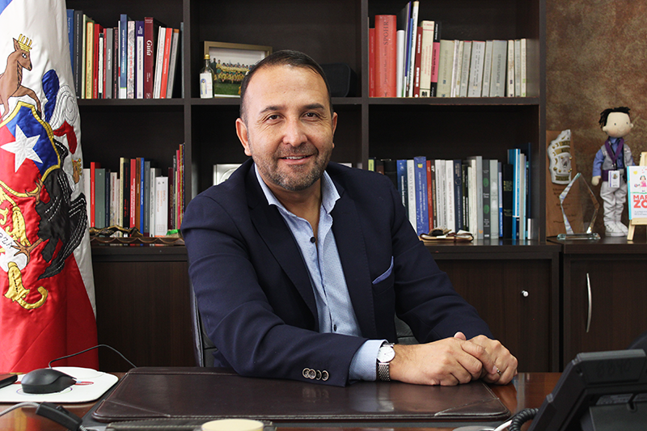

Gustavo Enrique Toro Quintana

(DC)

👥 Concejo municipal

8 concejales/as registrados

Estefanía Ñanculef

(Ind.)

Fidel Contreras

(Ind.)

Maximiliano Morel

(Ind.)

Max Pardo

(Ind.)

Claudio Tapia

(Ind.)

Judith Marín

(Ind.)

María Isabel Jopia

(Ind.)

Por confirmar

(Ind.)

🗺️ Red comunal

Mapa integrado de establecimientos y municipio · Comuna de San Ramón

Esta visualización ubica en un solo mapa a **escuelas y liceos**, **jardines infantiles** y la **municipalidad**. Al hacer clic en cada punto se abre una ficha breve con foco en matrícula y asistencia.

📍 19 puntos visibles

🏫 Escuelas y liceos

12

Asistencia ref.: Agosto 2026

🌱 Jardines infantiles

6

Corte ref.: Agosto 2026

📚 Matrícula total red

3.286

escuelas + jardines

🧭 Asistencia referencial

E/L 86% · JI 75.2%

promedio ponderado por matrícula

**Lectura del mapa:** 🏫 azul para escuelas y liceos, 🌱 lila para jardines infantiles y 🏛️ ámbar para la municipalidad. Los popups territoriales privilegian la lectura de matrícula y asistencia, manteniendo una referencia resumida de oferta educativa.  
Nota: el punto municipal se ubicó como referencia territorial cuando la base no trajo coordenadas explícitas.

[interactive chart not shown]

# 🗺️ Red Territorial

🗺️

Lectura territorial comunal

La portada ya deja el contexto institucional y comunal. Ahora el mapa abre la lectura espacial de **escuelas, liceos, jardines infantiles y municipio** para entrar después al detalle temático del informe.

📊

Panorama General · Comuna de San Ramón

Datos actualizados a Agosto 2026

🔄

**Cobertura del panorama comunal** 🏫 Escuelas y liceos 🌱 Jardines infantiles

En esta sección se mostrará la información consolidada de las escuelas, liceos y jardines infantiles de la comuna de San Ramón, integrando ambas redes en una lectura territorial con la paleta institucional del SLEP Santa Rosa.

Red educativa total

(Escuelas/Liceos + Jardines Infantiles)

📊 Matrícula Total

3.286

estudiantes + párvulos

🏫 Establecimientos

18

escuelas, liceos y jardines

📈 Promedio por EE

183

matrícula por establecimiento

🏫 Escuelas y Liceos

2.867

12 establecimientos · 87.2% del total

🌱 Jardines Infantiles

419

6 jardines · 12.8% del total

🏫 Escuelas y Liceos

(Agosto 2026)

👨‍🎓 Matrícula EyL

2.867

estudiantes activos

🏫 Establecimientos

12

escuelas y liceos

🗓️ Asistencia Promedio

86%

días asistidos/matriculados

🌱 Jardines Infantiles

(Agosto 2026)

👶 Matrícula JI

419

párvulos activos

🌿 Jardines

6

unidades del servicio

📅 Asistencia Promedio

75.2%

días asistidos/matriculados

Composición de matrícula por nivel

Escuelas, liceos y jardines infantiles de la comuna

Jardines Infantiles

🌱

Nivel Medio

199

párvulos

6.2%

4 jardines

Jardines Infantiles

🍼

Sala Cuna

147

párvulos

4.6%

6 jardines

Escuelas y Liceos

📚

Básica Niños

1.526

estudiantes

47.5%

9 establecimientos

Escuelas y Liceos

📖

Media HC Adultos

427

estudiantes

13.3%

3 establecimientos

Escuelas y Liceos

⚛️

Media HC Jóvenes

287

estudiantes

8.9%

3 establecimientos

Escuelas y Liceos

🏫

Parvularia

234

estudiantes

7.3%

9 establecimientos

Escuelas y Liceos

🛠️

Media TP Jóvenes

234

estudiantes

7.3%

3 establecimientos

Escuelas y Liceos

🌙

Básica Adultos

129

estudiantes

4%

2 establecimientos

Escuelas y Liceos

🔧

Media TP Adultos

30

estudiantes

0.9%

1 establecimientos

**📅 Corte vigente:** Agosto 2026. La matrícula presentada en esta tabla proviene de la **tabla consolidada de matrícula y asistencia**.

### 🏫 Establecimientos de Comuna de San Ramón

12 establecimientos con matrícula activa

| Logo | Establecimiento | Director(a) | Comuna | Matrícula | Niveles | IVE EE 2026 | IVE Com. 2026 | SNCAE |
| --- | --- | --- | --- | --- | --- | --- | --- | --- |
|  | Liceo Araucania RBD 9586 | Jorge Héctor Ávila Pérez | San Ramón | 363 | 🏫 Parvularia · 🌙 Básica Adultos · 📚 Básica Niños · 📖 Media HC Adultos | – | – | Sin certificación |
|  | Liceo Purkuyen RBD 9599 | Alejandro José Troncoso Lillo | San Ramón | 325 | 🏫 Parvularia · 📚 Básica Niños · ⚛️ Media HC Jóvenes · 🛠️ Media TP Jóvenes | – | – | Sin certificación |
|  | Escuela Especial De Adultos Ceia San Ramón RBD 9631 | HUBBER CRISTOPHER COLLARTE TARDÓN | San Ramón | 318 | 🌙 Básica Adultos · 📖 Media HC Adultos | – | – | Sin certificación |
|  | Centro Educacional Municipal San Ramon RBD 9601 | Rodrigo Alejandro Contreras Espinoza | San Ramón | 287 | 📖 Media HC Adultos · ⚛️ Media HC Jóvenes · 🔧 Media TP Adultos · 🛠️ Media TP Jóvenes | – | – | 🌿 Medio |
|  | Escuela Nanihue RBD 9600 | Nancy Edith Gallardo Onel | San Ramón | 254 | 🏫 Parvularia · 📚 Básica Niños | – | – | Sin certificación |
|  | Escuela Basica Sendero Del Saber RBD 9592 | Catalina Vanessa Reyes Pardo | San Ramón | 243 | 🏫 Parvularia · 📚 Básica Niños | – | – | Sin certificación |
|  | Escuela Basica Villa La Cultura RBD 9625 | Tania Angelica Montenegro Jimenez | San Ramón | 214 | 🏫 Parvularia · 📚 Básica Niños | – | – | Sin certificación |
|  | Escuela Basica Aliven RBD 9629 | Claudio Alejandro Parra Oñate | San Ramón | 211 | 🏫 Parvularia · 📚 Básica Niños | – | – | Sin certificación |
|  | Escuela Basica Tupahue RBD 9611 | Marcela Jeaninna Valenzuela Lara | San Ramón | 185 | 🏫 Parvularia · 📚 Básica Niños | – | – | Sin certificación |
|  | Escuela Basica Karelmapu RBD 9614 | Elsa Paola Becerra Albanez | San Ramón | 183 | 🏫 Parvularia · 📚 Básica Niños | – | – | Sin certificación |
|  | Escuela Basica Educadores De Chile RBD 9593 | JORGE ANTONIO AHUMADA VELÁSQUEZ | San Ramón | 164 | 🏫 Parvularia · 📚 Básica Niños | – | – | Sin certificación |
|  | Centro Educacional Mirador RBD 9608 | Yosires Betel González Montecinos | San Ramón | 120 | ⚛️ Media HC Jóvenes · 🛠️ Media TP Jóvenes | – | – | Sin certificación |

### 🌱 Jardines Infantiles de Comuna de San Ramón

6 jardines filtrados por comuna

**📍 Fuente y filtro:** tabla de jardines del informe 04, filtrada para San Ramón. La matrícula corresponde al **último corte disponible** (Agosto 2026). Se muestra además la **directora** y los **niveles ofertados**.

Logo

Jardín Infantil

Directora

Matrícula

Niveles

Jardin Infantil Semillitas De Esperanza

RBD 13131010

Cynthia Karina Pizarro Espinoza

95

👶 Sala Cuna · 🧒 Nivel Medio

Jardin Infantil Akun Pichiwentxu

RBD 13131015

Marisol Figueroa Ulloa

88

👶 Sala Cuna · 🧒 Nivel Medio

Jardin Infantil Caballito Feliz

RBD 13131014

Elizabeth Del Carmen Oñate González

75

👶 Sala Cuna · 🧒 Nivel Medio

Jardin Infantil La Hormiguita

RBD 13131005

Diana Caroline Martínez Martínez

70

👶 Sala Cuna · 🧒 Nivel Medio

Jardin Infantil Modelo

RBD 13131016

Natalia Andrea Calderon Borquez

51

👶 Sala Cuna · 🧒 Nivel Medio

Jardin Infantil Principes Del Reino

RBD 13131009

Anabel Graciela del Valle Bastias

40

👶 Sala Cuna · 🧒 Nivel Medio

📊

Datos complementarios al desempeño académico

Indicadores de contexto escolar

SNCAE

Sistema Nacional de Certificación Ambiental

Ministerio de Medio Ambiente

Indicador institucional que muestra si el establecimiento participa en el sistema de certificación ambiental y el **nivel alcanzado** . Su lectura es cualitativa: permite distinguir el grado de avance en educación ambiental, gestión sustentable y trabajo con la comunidad.

Cómo leerlo en la ficha Sin certificación o nivel alcanzado

Participación Voluntaria

Tipo de dato Cualitativo

Básico Medio Excelencia

IVE-JUNAEB

Índice de Vulnerabilidad Escolar

JUNAEB

Indicador que estima el porcentaje de estudiantes en situación de **vulnerabilidad socioeducativa** . Se expresa entre 0% y 100%: a mayor valor, mayor concentración de estudiantes con prioridad social. En esta edición se presenta el **IVE SINAE 2026 del establecimiento** junto con su **referencia comunal 2026** .

Escala 0% — 100%

Cómo leerlo en la ficha Mayor porcentaje = mayor vulnerabilidad; comparar con referencia comunal

Versiones IVE establecimiento 2026 + IVE comunal 2026

IVE EE 2026 IVE Comunal 2026 Serie metodológica vigente

SNED

Sistema Nacional de Evaluación del Desempeño

Desempeño de excelencia

Indicador que identifica establecimientos con **desempeño de excelencia** dentro de grupos comparables. En la ficha se interpreta de forma binaria: el establecimiento **obtuvo o no obtuvo SNED** en el proceso vigente.

Cómo leerlo en la ficha Sí obtuvo o no obtuvo SNED

Periodicidad Proceso bianual

Comparación Entre establecimientos semejantes

Tipo de dato Binario

Resultado binario Desempeño de excelencia Comparación entre pares

# 🌿 Certificación Ambiental SNCAE

# 📈 IVE SINAE 2026 y referencia comunal

#### 🌿 Certificación Ambiental SNCAE

Con Certificación

1

(8.3% del total)

Sin Certificación

11

##### 📋 Establecimientos con Certificación SNCAE

| Logo | RBD | Establecimiento | Comuna | Nivel SNCAE |
| --- | --- | --- | --- | --- |
|  | 9601 | Centro Educacional Municipal San Ramon | San Ramón | Medio |

#### 📈 IVE SINAE 2026 y referencia comunal

El análisis se construye con el IVE SINAE 2026 disponible para cada establecimiento y su referencia comunal vigente. La lectura se presenta según la serie metodológica actual.

IVE promedio EE

–

0 establecimientos con dato

IVE comunal 2026

–

0 comunas

IVE EE sobre 80

0

0% de los establecimientos con dato

Sobre ref. comunal

0

0% de los EE comparables

##### 🏫 IVE establecimiento 2026

| Tramo | N° EE | % |
| --- | --- | --- |
| 0-20% | 0 | 0,0% |
| 21-40% | 0 | 0,0% |
| 41-60% | 0 | 0,0% |
| 61-80% | 0 | 0,0% |
| 81-100% | 0 | 0,0% |

##### 🏙️ Referencia comunal 2026

| Comuna | IVE comunal | N° EE |
| --- | --- | --- |
| Sin referencias comunales disponibles. |  |  |

La referencia comunal se informa con la base 2026 vigente para cada territorio. Esta sección reemplaza la lectura histórica basada en aperturas metodológicas anteriores.

# 🏆 SNED

### 🏆 Sistema Nacional de Evaluación del Desempeño (SNED) - Comuna de San Ramón

El **SNED** es un instrumento de política pública del Estado de Chile que evalúa y reconoce el desempeño de los establecimientos educacionales en función de múltiples indicadores de calidad y equidad educativa. Considera dimensiones como la efectividad, superación, iniciativa, mejoramiento, igualdad e integración. Los establecimientos con mejor desempeño relativo acceden a la **Subvención por Desempeño de Excelencia**.

Participan en SNED

12

de 12 establecimientos

🏆 Seleccionados

2

Subvención de Excelencia

No Seleccionados

10

Índice SNED Promedio

57.19

Promedio SLEP

##### 🏆 Establecimientos Seleccionados - Subvención de Excelencia

RBD 9625

Escuela Basica Villa La Cultura

San Ramón

Índice

66.9

RBD 9593

Escuela Basica Educadores De Chile

San Ramón

Índice

66.45

##### 📊 Desglose de Factores - Promedio SLEP

Efectividad37%

Mide el nivel de resultados educativos alcanzados, considerando el desempeño en pruebas SIMCE.

31.2%

📋 12 establecimientos con datos

Superación28%

Evalúa los avances en resultados educativos a lo largo del tiempo.

65%

📋 12 establecimientos con datos

Iniciativa6%

Considera la capacidad para innovar y fortalecer el proyecto educativo.

51.9%

📋 12 establecimientos con datos

Mejoramiento2%

Evalúa el cumplimiento normativo y funcionamiento institucional.

99.8%

📋 12 establecimientos con datos

Integración5%

Evalúa la participación de la comunidad educativa.

42.9%

📋 12 establecimientos con datos

Igualdad22%

Mide el grado de inclusión e igualdad de oportunidades.

91.9%

📋 12 establecimientos con datos

# 🧑‍🎓 Concentración alumnos prioritarios

### 📊 Concentración · Alumnado Prioritario

2025 · Promedio Comuna

63.8%

2026 · Promedio Comuna

62.1%

Variación Promedio

↓ 1.7 pp

Comparación 2026 vs 2025

| Logo | RBD | Establecimiento | 2025 Concentración | 2026 Concentración | Variación |
| --- | --- | --- | --- | --- | --- |
|  | 9611 | ESCUELA BASICA TUPAHUE 📅 Marzo Mantienen ACAP | 87.5% | 85.3% | ↓ 2.2 pp |
|  | 9625 | ESCUELA BASICA VILLA LA CULTURA 📅 Marzo Mantienen ACAP | 78.1% | 77.4% | ↓ 0.7 pp |
|  | 9629 | ESCUELA BASICA ALIVEN 📅 Marzo Mantienen ACAP | 72.2% | 77.2% | ↑ +5.1 pp |
|  | 9599 | LICEO MUNICIPAL PURKUYEN 📅 Marzo Mantienen ACAP | 69.5% | 69.4% | ↓ 0.1 pp |
|  | 9600 | ESCUELA NANIHUE 📅 Marzo Mantienen ACAP | 67.9% | 68.2% | ↑ +0.3 pp |
|  | 9593 | ESCUELA BASICA EDUCADORES DE CHILE 📅 Marzo Mantienen ACAP | 69.8% | 66.1% | ↓ 3.6 pp |
|  | 9614 | ESCUELA BASICA KARELMAPU 📅 Marzo Mantienen ACAP | 73.3% | 64.9% | ↓ 8.4 pp |
|  | 9601 | CENTRO EDUCACIONAL MUNICIPAL SAN RAMON 📅 Marzo Mantienen ACAP | 67.8% | 62% | ↓ 5.8 pp |
|  | 9608 | CENTRO EDUCACIONAL MIRADOR 📅 Marzo Mantienen ACAP | 62% | 61.9% | ↓ 0.2 pp |
|  | 9592 | ESCUELA BASICA SENDERO DEL SABER 📅 Marzo Sin ACAP 2025-2026 | 54% | 49.4% | ↓ 4.6 pp |
|  | 9586 | LICEO MUNICIPALIZADO ARAUCANIA 📅 Marzo Sin ACAP 2025-2026 | 35.3% | 34.6% | ↓ 0.8 pp |
|  | 9631 | ESCUELA ESPECIAL DE ADULTOS 📅 Marzo Sin ACAP 2025-2026 | 28.4% | 29.2% | ↑ +0.8 pp |

ℹ️ Lectura de la tabla:↑ Aumento en concentración de alumnado prioritario | ↓ Disminución en concentración | 2025 vs 2026

### 🛠️ Establecimientos Técnico-Profesionales

3

Establecimientos TP

Matrícula Total TP

Establecimientos que imparten educación Media Técnico-Profesional con diversas especialidades según demanda territorial y proyecto educativo.

| Logo | RBD | Establecimiento | Comuna | Matrícula | Especialidades |
| --- | --- | --- | --- | --- | --- |
|  | 9599 | Liceo Purkuyen | San Ramón | 371 | 📂 Administración (mención)🩺 Atención de Enfermería (con mención) |
|  | 9601 | Centro Educacional Municipal San Ramon | San Ramón | 339 | 🏗️ Construcción (mención)⚡ Electricidad👵 Atención Adultos Mayores🩺 Atención Enfermería🩺 Atención de Enfermería (con mención) |
|  | 9608 | Centro Educacional Mirador | San Ramón | 139 | 🔌 Electrónica👨‍🍳 Gastronomía (mención) |

##### 📋 Resumen de Especialidades Impartidas en el SLEP

**8** especialidades distintas impartidas en **3** establecimientos TP.

🩺 Atención de Enfermería (con mención)2 EE

📂 Administración (mención)1 EE

🏗️ Construcción (mención)1 EE

⚡ Electricidad1 EE

🔌 Electrónica1 EE

👨‍🍳 Gastronomía (mención)1 EE

👵 Atención Adultos Mayores1 EE

🩺 Atención Enfermería1 EE

# 🏫 Resumen Matrícula

📊 Sección

Detalle de Matrícula · Comuna de San Ramón

Escuelas, liceos y jardines infantiles de la red comunal

📍 Vista comunal integrada

La **matrícula** corresponde al registro de niños, niñas y estudiantes vigentes en cada establecimiento del territorio. En esta sección se presentan de manera complementaria los detalles de matrícula de **escuelas y liceos** y de **jardines infantiles** de la comuna de San Ramón. La lectura integrada permite comparar volumen, distribución por establecimiento y composición por nivel educativo dentro de la red comunal del **SLEP Santa Rosa**.

🏫Escuelas y Liceos

▸Fuente principal: **CEM · SIGE · Mineduc** vía DEP.

▸Corte de referencia: **Agosto 2026**.

▸Se desagrega por establecimiento, género, nacionalidad, pueblos originarios, grado y nivel educativo.

🌱Jardines Infantiles

▸Fuente principal: **Gesparvu / GPW JUNJI** consolidada en el informe comunal.

▸Corte de referencia: **Agosto 2026**.

▸Se muestra matrícula por jardín, distribución por Sala Cuna, Nivel Medio y Transición, junto con asistencia y capacidad cuando existen datos.

🧭Cómo leer esta sección

▸Primero se presenta el **detalle de escuelas y liceos** con su composición de matrícula y variables sociodemográficas.

▸Luego se presenta el **detalle de jardines infantiles**, con foco en volumen de párvulos, niveles ofertados y desempeño del corte vigente.

📊 Panorama consolidado

Matrícula de escuelas y liceos

Información agregada de los establecimientos de la comuna de San Ramón. **Fuente:** Centro de Estudios del Mineduc (CEM).

📅 Datos a: Agosto 2026🔄 Actualización mensual

👥

##### Resumen matrícula

Total estudiantes

2.867

📅 Agosto 2026

👥

🏫 Establecimientos activos**12**

🌍 Estudiantes extranjeros**754 (26,3%)**

🌎

##### Composición

Género

👦 Masculino**1.514** (52,8%)

👧 Femenino**1.353** (47,2%)

Origen

🇨🇱 Chilenos**2.113** (73,7%)

🌍 Extranjeros**754** (26,3%)

🌿

##### Pueblos originarios

🌿 Mapuche**160** (5,6%)

🌐 Otra etnia**12** (0,4%)

☀️ Aymara**5** (0,2%)

🏺 Diaguita**2** (0,1%)

🏔️ Quechua**1** (0,0%)

🗺️

##### Nacionalidades

🇨🇱 Chilena**2.268** (79,1%)

🇻🇪 Venezolana**201** (7,0%)

🇭🇹 Haitiana**53** (1,8%)

🌐 Otra**52** (1,8%)

🇵🇪 Peruana**52** (1,8%)

🇨🇴 Colombiana**47** (1,6%)

🇪🇨 Ecuatoriana**18** (0,6%)

🇧🇴 Boliviana**10** (0,3%)

🇩🇴 Dominicana**5** (0,2%)

🇦🇷 Argentina**3** (0,1%)

🇧🇷 Brasilera**2** (0,1%)

🇰🇷 Coreana**1** (0,0%)

📊

##### Matrícula por nivel

🏫 Parvularia**234** (8,2%)

📚 Básica Niños**1.526** (53,2%)

⚛️ Media HC Jóvenes**287** (10,0%)

🛠️ Media TP Jóvenes**234** (8,2%)

🌙 Básica Adultos**129** (4,5%)

📖 Media HC Adultos**427** (14,9%)

🔧 Media TP Adultos**30** (1,0%)

🛠️

##### Matrícula TP por especialidad

🩺 Atención de Enfermería**87** (3,0%)

🏗️ Construcción (con mención)**34** (1,2%)

👨‍🍳 Gastronomía (con mención)**32** (1,1%)

⚡ Electricidad**31** (1,1%)

🔌 Electrónica**31** (1,1%)

👵 Atención de adultos mayores**30** (1,0%)

📂 Administración**19** (0,7%)

🎓

##### Detalle por curso

Distribución total de estudiantes por curso o grado en el último período disponible.

Pre-kínder**121** (4,2%)

Kínder**113** (3,9%)

1° Básico**144** (5,0%)

2° Básico**190** (6,6%)

3° Básico**169** (5,9%)

4° Básico**207** (7,2%)

5° Básico**208** (7,3%)

6° Básico**188** (6,6%)

7° Básico**223** (7,8%)

8° Básico**197** (6,9%)

1° Medio**122** (4,3%)

2° Medio**150** (5,2%)

3° Medio**126** (4,4%)

4° Medio**123** (4,3%)

Nivel Básico 1 (1° a 4° Básico)**16** (0,6%)

Nivel Básico 2 (5° y 6° Básico)**28** (1,0%)

Nivel Básico 3 (7° y 8° Básico)**85** (3,0%)

1° Nivel (Adultos)**196** (6,8%)

2° Nivel (Adultos)**256** (8,9%)

3° Nivel (Adultos)**5** (0,2%)

##### 🏫 Detalle de Matrícula por Establecimiento

Desglose completo de 12 establecimientos con matrícula activa.

| Logo | Establecimiento | 📊 Matrícula Total | 👥 Género 👨 M | 👥 Género 👩 F | 🌎 Nacionalidad 🏔️ Chi | 🌎 Nacionalidad 🌍 Ext | 🌎 Nacionalidad 📄 Nac | 🌿 Pueblos Orig. N° |
| --- | --- | --- | --- | --- | --- | --- | --- | --- |
|  | Liceo Araucania RBD 9586 | 363 12,7% | 190 | 173 | 219 | 144 (39,7%) | 0 | 10 |
|  | Liceo Purkuyen RBD 9599 | 325 11,3% | 157 | 168 | 228 | 97 (29,8%) | 0 | 17 (5,2%) |
|  | Escuela Especial De Adultos Ceia San Ramón RBD 9631 | 318 11,1% | 157 | 161 | 252 | 66 (20,8%) | 0 | 10 (3,1%) |
|  | Centro Educacional Municipal San Ramon RBD 9601 | 287 10,0% | 141 | 146 | 217 | 70 (24,4%) | 0 | 19 (6,6%) |
|  | Escuela Nanihue RBD 9600 | 254 8,9% | 139 | 115 | 191 | 63 (24,8%) | 0 | 32 (12,6%) |
|  | Escuela Basica Sendero Del Saber RBD 9592 | 243 8,5% | 137 | 106 | 149 | 94 (38,7%) | 0 | 5 |
|  | Escuela Basica Villa La Cultura RBD 9625 | 214 7,5% | 120 | 94 | 187 | 27 (12,6%) | 0 | 19 (8,9%) |
|  | Escuela Basica Aliven RBD 9629 | 211 7,4% | 110 | 101 | 155 | 56 (26,5%) | 0 | 26 (12,3%) |
|  | Escuela Basica Tupahue RBD 9611 | 185 6,5% | 96 | 89 | 173 | 12 (6,5%) | 0 | 24 (13,0%) |
|  | Escuela Basica Karelmapu RBD 9614 | 183 6,4% | 101 | 82 | 136 | 47 (25,7%) | 0 | 5 |
|  | Escuela Basica Educadores De Chile RBD 9593 | 164 5,7% | 89 | 75 | 124 | 40 (24,4%) | 0 | 7 (4,3%) |
|  | Centro Educacional Mirador RBD 9608 | 120 4,2% | 77 | 43 | 82 | 38 (31,7%) | 0 | 6 (5,0%) |
| TOTAL COMUNA |  | 2.867 | 1.514 | 1.353 | 2.113 | 754 | 0 | 180 |

👶

Jardines Infantiles

Detalle de Matrícula de Jardines — Comuna de San Ramón

Gesparvu / GPW JUNJI · Corte vigente: Agosto 2026

6 jardines filtrados

📅 Corte

Agosto 2026

👶 Matrícula del corte

419

párvulos activos

🏡 Jardines con matrícula

6

unidades con movimiento

🚻 Matrícula por género

👦 Masculino**182 (50.8%)**

👧 Femenino**176 (49.2%)**

🧭 Asistencia agregada

75.2%

días asistidos / matriculados

Sala Cuna

147

párvulos

35.1%

6 jardines

Nivel Medio

199

párvulos

47.5%

4 jardines

Grado 11

73

párvulos

17.4%

3 jardines

##### 🏫 Detalle de Matrícula por Jardín Infantil

Desglose completo de 6 jardines con matrícula activa en el corte seleccionado.

Logo

Jardín Infantil

📊 Matrícula

🍼 Niveles del corte

🧭 Asistencia

Total

👶 Sala Cuna

🧒 Nivel Medio

🎒 Transición

%

Jardin Infantil Semillitas De Esperanza

RBD 13131010

👩‍🏫 Cynthia Karina Pizarro Espinoza

95

22.7%

40

(42.1%)

55

(57.9%)

0

86.7%

cap. 124

Jardin Infantil Akun Pichiwentxu

RBD 13131015

👩‍🏫 Marisol Figueroa Ulloa

88

21%

28

(31.8%)

60

(68.2%)

0

79.2%

cap. 95

Jardin Infantil Caballito Feliz

RBD 13131014

👩‍🏫 Elizabeth Del Carmen Oñate González

75

17.9%

30

(40%)

45

(60%)

0

72.2%

cap. 98

Jardin Infantil La Hormiguita

RBD 13131005

👩‍🏫 Diana Caroline Martínez Martínez

70

16.7%

18

(25.7%)

39

(55.7%)

0

65.8%

cap. 116

Jardin Infantil Modelo

RBD 13131016

👩‍🏫 Natalia Andrea Calderon Borquez

51

12.2%

19

(37.3%)

0

0

70.3%

cap. 52

Jardin Infantil Principes Del Reino

RBD 13131009

👩‍🏫 Anabel Graciela del Valle Bastias

40

9.5%

12

(30%)

0

0

67.4%

cap. 46

TOTAL COMUNA

419

147

199

0

# 🕰️ Evolución Matricula

🕰️ Sección

Evolución Histórica de la Matrícula

CEM · SIGE · Serie histórica anual

📈 Tendencia Histórica

La **evolución histórica de matrícula** muestra cómo ha variado el número de estudiantes inscritos a lo largo de los años en los establecimientos de la comuna de San Ramón. Esta tendencia es un indicador estructural del territorio: refleja cambios demográficos, migraciones, decisiones de familias sobre el tipo de educación y el impacto de políticas públicas como la **Ley SEP (Subvención Escolar Preferencial)** o las campañas de permanencia escolar. Un descenso sostenido de matrícula en el sector público puede indicar un proceso de **“fuga” hacia el sector subvencionado**, lo que requiere análisis territorial.

📊Cómo leer la tendencia

▸Se compara el **promedio mensual de matrícula de cada año**, resumiendo la serie consolidada disponible.

▸**Variación % interanual:** caídas de más de 3% en un año son señal de alerta para la gestión territorial.

🌐Factores que afectan la matrícula

▸**Demográficos:** tasas de natalidad, migraciones internas, densificación urbana.

▸**Elección de familias:** oferta de establecimientos privados subvencionados en el territorio.

## 📈 Evolución Histórica de la Matrícula de Escuelas y Liceos - Comuna de San Ramón

#### 📊 Panel de Análisis Histórico

Visualización del **promedio anual de matrícula** construido desde la serie mensual consolidada. **Fuente:** Centro de Estudios del Mineduc (CEM).

📅 Último Año

2026

👨‍🎓 Matrícula Promedio

2.836

Promedio mensual del año

📊 Var. Interanual

-4.4%

🏫 Estab. Promedio

12

6 meses considerados

[interactive chart not shown]

##### 🏫 Matrícula Promedio por Establecimiento y Año

Comparativa anual de matrícula promedio por establecimiento. **Nota:** La variación porcentual (Var.) se calcula comparando el promedio de matrícula del año **2026** respecto al promedio del año **2025**.

| Logo | RBD | Establecimiento | Comuna | 2016 | 2017 | 2018 | 2019 | 2022 | 2023 | 2024 | 2025 | 2026 | Var. % |
| --- | --- | --- | --- | --- | --- | --- | --- | --- | --- | --- | --- | --- | --- |
|  | 9586 | Liceo Araucania | San Ramón | 491 | 496 | 543 | 558 | 476 | 451 | 378 | 362 | 343 | -5.2% |
|  | 9599 | Liceo Purkuyen | San Ramón | 572 | 614 | 530 | 490 | 429 | 430 | 416 | 359 | 324 | -9.7% |
|  | 9631 | Escuela Especial De Adultos Ceia San Ramón | San Ramón | 537 | 507 | 534 | 525 | 409 | 403 | 327 | 309 | 304 | -1.6% |
|  | 9601 | Centro Educacional Municipal San Ramon | San Ramón | 410 | 394 | 353 | 338 | 281 | 285 | 308 | 336 | 286 | -14.9% |
|  | 9600 | Escuela Nanihue | San Ramón | 293 | 283 | 288 | 272 | 261 | 257 | 258 | 255 | 260 | +2% |
|  | 9592 | Escuela Basica Sendero Del Saber | San Ramón | 220 | 208 | 215 | 242 | 267 | 273 | 286 | 245 | 248 | +1.2% |
|  | 9629 | Escuela Basica Aliven | San Ramón | 429 | 352 | 305 | 257 | 254 | 248 | 211 | 196 | 212 | +8.2% |
|  | 9625 | Escuela Basica Villa La Cultura | San Ramón | 384 | 342 | 323 | 280 | 249 | 237 | 235 | 228 | 204 | -10.5% |
|  | 9611 | Escuela Basica Tupahue | San Ramón | 278 | 240 | 235 | 241 | 196 | 175 | 172 | 186 | 184 | -1.1% |
|  | 9614 | Escuela Basica Karelmapu | San Ramón | 269 | 258 | 274 | 276 | 234 | 226 | 200 | 189 | 181 | -4.2% |
|  | 9593 | Escuela Basica Educadores De Chile | San Ramón | 206 | 193 | 189 | 192 | 199 | 192 | 174 | 165 | 162 | -1.8% |
|  | 9608 | Centro Educacional Mirador | San Ramón | 222 | 173 | 185 | 180 | 111 | 133 | 119 | 138 | 127 | -8% |

##### 📈 Top 10 Mayor Crecimiento (2025 → 2026)

1

Escuela Basica Aliven

RBD 9629 • San Ramón

+8.2%

2

Escuela Nanihue

RBD 9600 • San Ramón

+2%

3

Escuela Basica Sendero Del Saber

RBD 9592 • San Ramón

+1.2%

4

Escuela Basica Tupahue

RBD 9611 • San Ramón

+-1.1%

5

Escuela Especial De Adultos Ceia San Ramón

RBD 9631 • San Ramón

+-1.6%

6

Escuela Basica Educadores De Chile

RBD 9593 • San Ramón

+-1.8%

7

Escuela Basica Karelmapu

RBD 9614 • San Ramón

+-4.2%

8

Liceo Araucania

RBD 9586 • San Ramón

+-5.2%

9

Centro Educacional Mirador

RBD 9608 • San Ramón

+-8%

10

Liceo Purkuyen

RBD 9599 • San Ramón

+-9.7%

##### 📉 Top 10 Mayor Decrecimiento (2025 → 2026)

1

Centro Educacional Municipal San Ramon

RBD 9601 • San Ramón

-14.9%

2

Escuela Basica Villa La Cultura

RBD 9625 • San Ramón

-10.5%

3

Liceo Purkuyen

RBD 9599 • San Ramón

-9.7%

4

Centro Educacional Mirador

RBD 9608 • San Ramón

-8%

5

Liceo Araucania

RBD 9586 • San Ramón

-5.2%

6

Escuela Basica Karelmapu

RBD 9614 • San Ramón

-4.2%

7

Escuela Basica Educadores De Chile

RBD 9593 • San Ramón

-1.8%

8

Escuela Especial De Adultos Ceia San Ramón

RBD 9631 • San Ramón

-1.6%

9

Escuela Basica Tupahue

RBD 9611 • San Ramón

-1.1%

10

Escuela Basica Sendero Del Saber

RBD 9592 • San Ramón

1.2%

🌱

Jardines Infantiles

Parte 2 · Jardines Infantiles — Evolución Histórica de Matrícula · Comuna de San Ramón

Gesparvu / GPW JUNJI · serie histórica comunal de párvulos matriculados

6 jardines filtrados

📊 Lectura histórica de jardines infantiles

Esta segunda parte presenta la **evolución histórica agregada de la matrícula en jardines infantiles** de la comuna de San Ramón. Se observan los cambios en el volumen de párvulos matriculados, la cantidad de jardines con registros vigentes y la composición promedio por nivel ofertado. **Fuente:** Gesparvu / GPW JUNJI.

📅 Último período

Agosto 2026

👶 Matrícula actual

419

párvulos matriculados

📈 Var. interanual

-3,7%

comparación con igual mes del año previo

🏡 Jardines observados

6

mejor registro: Octubre 2024

Últimos 12 períodos observados · Jardines infantiles

| Período | Matrícula | Jardines | Var. período |
| --- | --- | --- | --- |
| Julio 2025 | 424 | 6 | +0,2% |
| Agosto 2025 | 435 | 6 | +2,6% |
| Septiembre 2025 | 439 | 6 | +0,9% |
| Octubre 2025 | 438 | 6 | -0,2% |
| Noviembre 2025 | 435 | 6 | -0,7% |
| Diciembre 2025 | 430 | 6 | -1,1% |
| Marzo 2026 | 373 | 6 | -13,3% |
| Abril 2026 | 388 | 6 | +4,0% |
| Mayo 2026 | 404 | 6 | +4,1% |
| Junio 2026 | 403 | 6 | -0,2% |
| Julio 2026 | 397 | 6 | -1,5% |
| Agosto 2026 | 419 | 6 | +5,5% |

# 🏫 Resumen asistencia

🧭 Sección

Evolución Histórica de Asistencia

SIGE · Ley SAE · Ausentismo crónico

📅 Ley SAE

La **asistencia escolar** mide qué porcentaje de los días hábiles en que un estudiante tenía matrícula vigente, efectivamente asistió al establecimiento. Se calcula como: **días asistidos ÷ días con matrícula activa × 100**. La **Ley SAE (Sistema de Alerta Escolar)** obliga a los establecimientos a reportar y gestionar el ausentismo. El **ausentismo crónico** se define como la inasistencia a más del 20% de los días hábiles y es un predictor fuerte de rezago, repitencia y abandono escolar.

⚠️Umbrales de alerta

▸**≥ 90%:** asistencia regular. Meta mínima del sistema.

▸**80–89%:** riesgo moderado. Requiere seguimiento individual.

▸**< 80%:** ausentismo crónico. Activación de protocolo SAE y reporte a la DEP.

💡Uso para la gestión

▸La tendencia histórica permite identificar si el ausentismo es **estructural** (se repite año a año) o **coyuntural** (asociado a eventos puntuales).

▸Útil para planificar recursos de **convivencia escolar, trabajo social y psicología** focalizado en establecimientos críticos.

📘 Panorama consolidado

Asistencia de escuelas y liceos

Información agregada de los establecimientos de la comuna de San Ramón. **Fuente:** Centro de Estudios del Mineduc (CEM). El cálculo se basa en días asistidos sobre días con matrícula activa.

📅 Datos a: Agosto 2026🎯 Meta referencial: 90%

📘

##### Resumen asistencia

Asistencia total

86,0%

📅 Agosto 2026

📘

👨‍🎓 Matrícula de referencia**2.867**

🏫 Establecimientos con dato**12**

🌎

##### Composición

Género

👦 Masculino**85,6%** · N 1.514

👧 Femenino**86,5%** · N 1.353

Origen

🇨🇱 Chilenos**84,3%** · N 2.113

🌍 Extranjeros**90,8%** · N 754

🌿

##### Pueblos originarios

🌿 Mapuche**86,4%** · N 160

🌐 Otra etnia**88,9%** · N 12

☀️ Aymara**90,5%** · N 5

🏺 Diaguita**85,7%** · N 2

🏔️ Quechua**95,2%** · N 1

🌐

##### Nacionalidades

🇨🇱 Chilena**85,3%** · N 2.268

🇻🇪 Venezolana**88,3%** · N 201

🇭🇹 Haitiana**95,2%** · N 53

🌐 Otra**91,6%** · N 52

🇵🇪 Peruana**90,3%** · N 52

🇨🇴 Colombiana**91,9%** · N 47

🇪🇨 Ecuatoriana**86,8%** · N 18

🇧🇴 Boliviana**89,3%** · N 10

🇩🇴 Dominicana**97,7%** · N 5

🇦🇷 Argentina**58,7%** · N 3

🇧🇷 Brasilera**100,0%** · N 2

🇰🇷 Coreana**61,9%** · N 1

📊

##### Asistencia por nivel

🏫 Parvularia**85,3%** · N 234

📚 Básica Niños**88,3%** · N 1.526

⚛️ Media HC Jóvenes**84,6%** · N 287

🛠️ Media TP Jóvenes**84,0%** · N 234

🌙 Básica Adultos**75,4%** · N 129

📖 Media HC Adultos**82,9%** · N 427

🔧 Media TP Adultos**92,3%** · N 30

🛠️

##### Asistencia TP por especialidad

🩺 Atención de Enfermería**80,7%** · N 87

🏗️ Construcción (con mención)**93,1%** · N 34

👨‍🍳 Gastronomía (con mención)**86,3%** · N 32

⚡ Electricidad**80,7%** · N 31

🔌 Electrónica**86,6%** · N 31

👵 Atención de adultos mayores**92,1%** · N 30

📂 Administración**79,6%** · N 19

🏫

##### Detalle por curso

Asistencia promedio del último período disponible por curso o grado.

Pre-kínder**83,9%** · N 121

Kínder**86,7%** · N 113

1° Básico**85,7%** · N 144

2° Básico**87,4%** · N 190

3° Básico**90,0%** · N 169

4° Básico**88,7%** · N 207

5° Básico**89,5%** · N 208

6° Básico**86,1%** · N 188

7° Básico**89,8%** · N 223

8° Básico**88,6%** · N 197

1° Medio**83,0%** · N 122

2° Medio**86,4%** · N 150

3° Medio**81,0%** · N 126

4° Medio**86,5%** · N 123

Nivel Básico 1 (1° a 4° Básico)**79,1%** · N 16

Nivel Básico 2 (5° y 6° Básico)**70,4%** · N 28

Nivel Básico 3 (7° y 8° Básico)**76,3%** · N 85

1° Nivel (Adultos)**79,0%** · N 196

2° Nivel (Adultos)**86,8%** · N 256

3° Nivel (Adultos)**96,2%** · N 5

##### 🏫 Detalle de Asistencia por Establecimiento

Desglose completo de 12 establecimientos con datos de asistencia en el último período disponible.

| Logo | Establecimiento | Comuna | 📊 Asistencia Total | 👥 Género 👨 M | 👥 Género 👩 F | 🌎 Nacionalidad 🏔️ Chi | 🌎 Nacionalidad 🌍 Ext | 🌎 Nacionalidad 📄 Nac | 👨‍🎓 N N° |
| --- | --- | --- | --- | --- | --- | --- | --- | --- | --- |
|  | Liceo Araucania RBD 9586 | San Ramón | 87,8% | 84,9% | 91,1% | 86,5% | 89,7% | – | 363 |
|  | Liceo Purkuyen RBD 9599 | San Ramón | 80,7% | 81,5% | 80,0% | 78,0% | 87,0% | – | 325 |
|  | Escuela Especial De Adultos Ceia San Ramón RBD 9631 | San Ramón | 76,7% | 74,8% | 78,6% | 73,7% | 87,9% | – | 318 |
|  | Centro Educacional Municipal San Ramon RBD 9601 | San Ramón | 89,2% | 89,5% | 88,9% | 87,9% | 93,5% | – | 287 |
|  | Escuela Nanihue RBD 9600 | San Ramón | 86,1% | 85,6% | 86,7% | 85,3% | 88,7% | – | 254 |
|  | Escuela Basica Sendero Del Saber RBD 9592 | San Ramón | 93,4% | 92,4% | 94,7% | 91,4% | 96,6% | – | 243 |
|  | Escuela Basica Villa La Cultura RBD 9625 | San Ramón | 87,9% | 88,6% | 87,0% | 86,9% | 94,9% | – | 214 |
|  | Escuela Basica Aliven RBD 9629 | San Ramón | 87,4% | 85,5% | 89,5% | 86,1% | 91,1% | – | 211 |
|  | Escuela Basica Tupahue RBD 9611 | San Ramón | 85,3% | 85,4% | 85,1% | 85,4% | 83,7% | – | 185 |
|  | Escuela Basica Karelmapu RBD 9614 | San Ramón | 88,3% | 88,8% | 87,8% | 86,5% | 93,4% | – | 183 |
|  | Escuela Basica Educadores De Chile RBD 9593 | San Ramón | 88,7% | 88,5% | 89,0% | 87,4% | 92,8% | – | 164 |
|  | Centro Educacional Mirador RBD 9608 | San Ramón | 85,0% | 85,7% | 85,1% | 83,8% | 88,3% | – | 120 |
| TOTAL COMUNA |  |  | 86,0% | 85,6% | 86,5% | 84,3% | 90,8% | – | 2.867 |

# 🧭 Evolucion Asistencia

## 📊 Evolución Histórica de la Asistencia de Escuelas y Liceos - Comuna de San Ramón

#### 📈 Panel de Análisis de Asistencia

Visualización de la evolución del porcentaje de asistencia. **Fuente:** Centro de Estudios del Mineduc (CEM).

📋 **Nota:** Asistencia calculada sobre días matriculados del estudiante.

📅 Último Período

Agosto 2026

📊 Asistencia Actual

86%

Estado: Aceptable

📈 Var. Interanual

+1.7 pp

🏫 Establecimientos

12

Umbrales de Asistencia:🟢 ≥90% Óptima🟡 85-89% Aceptable🟠 80-84% En riesgo🔴 <80% Crítica

[interactive chart not shown]

##### 🏫 Asistencia Promedio por Establecimiento y Año

Comparativa anual de asistencia promedio por establecimiento. **Nota:** La variación (Var.) se expresa en **puntos porcentuales (pp)** y compara el promedio de asistencia del año **2026** respecto al año **2025**.

| Logo | RBD | Establecimiento | Comuna | 2016 | 2017 | 2018 | 2019 | 2022 | 2023 | 2024 | 2025 | 2026 | Var. (pp) |
| --- | --- | --- | --- | --- | --- | --- | --- | --- | --- | --- | --- | --- | --- |
|  | 9592 | Escuela Basica Sendero Del Saber | San Ramón | 87.8% | 89.9% | 92.5% | 90.8% | 91.3% | 88.9% | 91.4% | 90.3% | 89.1% | -1.2 pp |
|  | 9614 | Escuela Basica Karelmapu | San Ramón | 84.3% | 89.9% | 89.7% | 88.8% | 79.9% | 80.6% | 85.4% | 87.8% | 88.4% | +0.6 pp |
|  | 9625 | Escuela Basica Villa La Cultura | San Ramón | 83.2% | 87.4% | 87.3% | 85.5% | 84.6% | 86.9% | 87.5% | 88.8% | 88.1% | -0.7 pp |
|  | 9608 | Centro Educacional Mirador | San Ramón | 78% | 87.6% | 89.2% | 84.9% | 81.3% | 80.3% | 88.1% | 84.4% | 87.9% | +3.5 pp |
|  | 9593 | Escuela Basica Educadores De Chile | San Ramón | 91.7% | 91.6% | 92.3% | 93% | 89.8% | 92% | 95.7% | 93.9% | 87.7% | -6.2 pp |
|  | 9601 | Centro Educacional Municipal San Ramon | San Ramón | 81.5% | 85.6% | 83.4% | 78.5% | 80.3% | 82.1% | 84.7% | 84.3% | 87.5% | +3.2 pp |
|  | 9586 | Liceo Araucania | San Ramón | 81.6% | 86.6% | 88.5% | 88.9% | 85.7% | 80.9% | 87.8% | 83.2% | 86.8% | +3.6 pp |
|  | 9600 | Escuela Nanihue | San Ramón | 81.8% | 88.1% | 85.6% | 88.6% | 77.4% | 83.6% | 88.1% | 87.9% | 85.2% | -2.7 pp |
|  | 9629 | Escuela Basica Aliven | San Ramón | 84.2% | 88.6% | 88.4% | 87.9% | 85.9% | 87.4% | 89.7% | 89.7% | 84.7% | -5 pp |
|  | 9611 | Escuela Basica Tupahue | San Ramón | 81.7% | 87.9% | 91.8% | 85.4% | 78.4% | 80.2% | 82.7% | 82.8% | 84.2% | +1.4 pp |
|  | 9599 | Liceo Purkuyen | San Ramón | 80% | 81.6% | 87.7% | 84.9% | 79.5% | 77.8% | 81.5% | 78.8% | 83.9% | +5.1 pp |
|  | 9631 | Escuela Especial De Adultos Ceia San Ramón | San Ramón | 74.3% | 77.5% | 85.8% | 87% | 87.4% | 81.1% | 83.6% | 78% | 71.4% | -6.6 pp |

##### 📈 Top 10 Mayor Mejora en Asistencia (2025 → 2026)

1

Liceo Purkuyen

RBD 9599 • San Ramón

+5.1 pp

Actual: 83.9%

2

Liceo Araucania

RBD 9586 • San Ramón

+3.6 pp

Actual: 86.8%

3

Centro Educacional Mirador

RBD 9608 • San Ramón

+3.5 pp

Actual: 87.9%

4

Centro Educacional Municipal San Ramon

RBD 9601 • San Ramón

+3.2 pp

Actual: 87.5%

5

Escuela Basica Tupahue

RBD 9611 • San Ramón

+1.4 pp

Actual: 84.2%

6

Escuela Basica Karelmapu

RBD 9614 • San Ramón

+0.6 pp

Actual: 88.4%

7

Escuela Basica Villa La Cultura

RBD 9625 • San Ramón

+-0.7 pp

Actual: 88.1%

8

Escuela Basica Sendero Del Saber

RBD 9592 • San Ramón

+-1.2 pp

Actual: 89.1%

9

Escuela Nanihue

RBD 9600 • San Ramón

+-2.7 pp

Actual: 85.2%

10

Escuela Basica Aliven

RBD 9629 • San Ramón

+-5 pp

Actual: 84.7%

##### 📉 Top 10 Mayor Disminución en Asistencia (2025 → 2026)

1

Escuela Especial De Adultos Ceia San Ramón

RBD 9631 • San Ramón

-6.6 pp

Actual: 71.4%

2

Escuela Basica Educadores De Chile

RBD 9593 • San Ramón

-6.2 pp

Actual: 87.7%

3

Escuela Basica Aliven

RBD 9629 • San Ramón

-5 pp

Actual: 84.7%

4

Escuela Nanihue

RBD 9600 • San Ramón

-2.7 pp

Actual: 85.2%

5

Escuela Basica Sendero Del Saber

RBD 9592 • San Ramón

-1.2 pp

Actual: 89.1%

6

Escuela Basica Villa La Cultura

RBD 9625 • San Ramón

-0.7 pp

Actual: 88.1%

7

Escuela Basica Karelmapu

RBD 9614 • San Ramón

0.6 pp

Actual: 88.4%

8

Escuela Basica Tupahue

RBD 9611 • San Ramón

1.4 pp

Actual: 84.2%

9

Centro Educacional Municipal San Ramon

RBD 9601 • San Ramón

3.2 pp

Actual: 87.5%

10

Centro Educacional Mirador

RBD 9608 • San Ramón

3.5 pp

Actual: 87.9%

🧭

Jardines Infantiles

Parte 2 · Jardines Infantiles — Evolución Histórica de Asistencia · Comuna de San Ramón

Gesparvu / GPW JUNJI · días asistidos sobre días matriculados

6 jardines filtrados

📊 Lectura histórica de asistencia en jardines

Esta segunda parte replica la lectura histórica para **jardines infantiles**, mostrando la evolución comunal de la asistencia promedio, la cantidad de jardines con registros y la trayectoria anual del indicador. **Fuente:** Gesparvu / GPW JUNJI.

📅 Último período

Agosto 2026

🧭 Asistencia actual

75.2%

Meta cumplida

📈 Var. interanual

+7,5 pp

comparación con igual mes del año previo

🏡 Jardines observados

6

mejor registro: Abril 2025

🚦 Umbrales de seguimiento para jardines:🟢 ≥75% Meta🟠 60% a 74,9% Alerta🔴 <60% Crítica

Últimos 12 períodos observados · Jardines infantiles

| Período | Asistencia | Jardines | Matrícula | Var. período |
| --- | --- | --- | --- | --- |
| Julio 2025 | 77.7% | 6 | 424 | +7,5 pp |
| Agosto 2025 | 67.7% | 6 | 435 | -10,0 pp |
| Septiembre 2025 | 69.9% | 6 | 439 | +2,2 pp |
| Octubre 2025 | 75.9% | 6 | 438 | +6,0 pp |
| Noviembre 2025 | 79.7% | 6 | 435 | +3,8 pp |
| Diciembre 2025 | 73.7% | 6 | 430 | -6,0 pp |
| Marzo 2026 | 65.1% | 6 | 373 | -8,6 pp |
| Abril 2026 | 81.4% | 6 | 388 | +16,3 pp |
| Mayo 2026 | 82.4% | 6 | 404 | +1,0 pp |
| Junio 2026 | 79% | 6 | 403 | -3,4 pp |
| Julio 2026 | 70.1% | 6 | 397 | -8,9 pp |
| Agosto 2026 | 75.2% | 6 | 419 | +5,1 pp |

# 💼 Ocupación establecimientos

💼 Sección

Ocupación de Establecimientos

SIGE · Capacidad instalada · Cupos disponibles

🏢 Capacidad Instalada

La **tasa de ocupación** de un establecimiento expresa qué porcentaje de su **capacidad instalada** está siendo efectivamente utilizada por estudiantes matriculados. Se calcula como: **matrícula vigente ÷ capacidad de atención × 100**. La capacidad de atención es el número máximo de estudiantes que puede recibir el establecimiento según su infraestructura y las normas del Mineduc. Establecimientos con baja ocupación generan **costos fijos elevados por alumno**, lo cual afecta la eficiencia del gasto público. En esta vista comunal se distinguen dos lecturas: **escuelas y liceos** con base en **capacidad SAE reportada**, y **jardines infantiles** con base en **cupos Gesparvu**, por lo que ambas se muestran por separado.

📐Rangos de ocupación

▸**≥ 85%:** uso eficiente de la infraestructura. Situación ideal.

▸**60–84%:** infraestructura subutilizada. Analizar causas (déficit de oferta, problemas de imagen).

▸**< 60%:** establecimiento en riesgo de cierre o fusión. Requiere intervención estratégica en el territorio.

💡Uso para la planificación

▸Permite identificar establecimientos con **cupos disponibles** para derivar matrículas desde sectores saturados.

▸Base para decisiones de **inversión en infraestructura, fusión de cursos o racionalización de la red** educativa comunal.

💼

Jardines Infantiles

Parte 2 · Jardines Infantiles — Ocupación de Jardines · Comuna de San Ramón

Cruce entre matrícula vigente y cupos Gesparvu

6 jardines filtrados

💼 Jardines Infantiles

Cómo se calcula la ocupación de jardines

Gesparvu (GPW) · JUNJI · estructura de cursos vigente

📐 Cupos Gesparvu

📏 Cómo se leen los cupos

Los cupos de los jardines infantiles se leen desde la **estructura de cursos Gesparvu (GPW) de JUNJI**, consolidada en la base **bd_estructura_cursos_jisc**. Esta referencia organiza la oferta vigente por nivel, grado y grupo para transparentar los cupos efectivos disponibles en cada unidad educativa.

📐 Superficie mínima

🍼 Sala Cuna

2,5 m2 por párvulo

🌱 Nivel Medio y Transición

1,1 m2 por párvulo

🎯 Cómo leerla

La ocupación se interpreta como matrícula sobre cupos Gesparvu. Esta vista permite distinguir jardines con holgura, alta ocupación y sobrecupo para priorizar gestión de vacantes y ajustes de oferta.

Ocupación global

78.9%

matrícula total sobre capacidad total

Alta ocupación

2

jardines entre 90% y 99,9%

Sobrecupo

0

jardines sobre 100% de cupos

Con holgura

1

jardines bajo 75% de ocupación

🌱 Parte 2 · Jardines Infantiles — Detalle de Ocupación

Se listan todos los jardines filtrados para la comuna. **Balance positivo** indica vacantes disponibles y **balance negativo** indica sobrecupo.

6 jardines con cupos

Logo

Jardín infantil

Cupos

Matrícula

Balance

Ocupación

Estado

Jardin Infantil Modelo

San Ramón · RBD 13131016

52

51

+1

vacantes

98.1%

51 / 52

🟠 ALTA

Jardin Infantil Akun Pichiwentxu

San Ramón · RBD 13131015

95

88

+7

vacantes

92.6%

88 / 95

🟠 ALTA

Jardin Infantil Principes Del Reino

San Ramón · RBD 13131009

46

40

+6

vacantes

87%

40 / 46

🔵 MEDIA

Jardin Infantil Semillitas De Esperanza

San Ramón · RBD 13131010

124

95

+29

vacantes

76.6%

95 / 124

🔵 MEDIA

Jardin Infantil Caballito Feliz

San Ramón · RBD 13131014

98

75

+23

vacantes

76.5%

75 / 98

🔵 MEDIA

Jardin Infantil La Hormiguita

San Ramón · RBD 13131005

116

70

+46

vacantes

60.3%

70 / 116

🟢 HOLGURA

# 🔄 Análisis de Retiros y Movilidad Estudiantil Comunal

📉 Movilidad Estudiantil · Visión Comunal

Análisis de Retiros y Movilidad — Comuna de San Ramón

🔄 Actualización Mensual

Consolida todos los movimientos de estudiantes de los establecimientos de la comuna de San Ramón, cruzando la base interna con el **SIGE** para determinar continuidad educativa. Se distingue el **destino de cada retiro** según la dependencia del establecimiento receptor.

🚪 Tipos de Movimiento

🔄 Colisión / Cambio interno (mismo RBD)

🏫 Cambio a EE del SLEP

🚪 Cambio a EE externo al SLEP

⚠️ Sin matrícula vigente en SIGE

📍 Dependencias de Destino

🏫 Mismo SLEP · 🔀 Otro SLEP

🏛️ Particular Subvencionado

💳 Particular Pagado

📋 Administración Delegada

⚠️ Sin Matrícula

📉 Retiros y Movilidad Estudiantil — Comuna de San Ramón

Seleccionar año de visualización

Año por defecto: 2026

📌 Datos visualizados: Año 2026 · último mes actualizado: Agosto

🚪 Total Retiros

375

Año 2026 · último mes actualizado: Agosto

✅ Con Continuidad

148

39.5% con matrícula

⚠️ Sin Matrícula SIGE

196

52.3% alerta

⏳ Pendiente SIGE

31

sin confirmación al corte

🔄 Cambios Internos

26

mismo colegio

🏫 EE con Retiros

12

establecimientos

⚠️ **52.3% de los estudiantes retirados** (196) no aparece con matrícula vigente en SIGE — posible riesgo de abandono escolar.

📅 Retiros por Mes · corte Agosto 2026

Mar73

Abr72

May62

Jun41

Jul63

Ago64

📍 Dependencia de Destino

⚠️ Sin Matrícula98

⚠️ Sin matrícula vigente98

🏛️ Part. Subvencionado90

🏫 Mismo SLEP52

🔀 Otro SLEP32

📋 Adm. Delegada5

📋 Tipo de Movimiento

⚠️ Sin matrícula196

🚪 Cambio a EE externo127

🏫 Cambio a EE del SLEP26

🔄 Colisión / Cambio interno26

📌 Datos visualizados: Año 2025 · último mes actualizado: Diciembre

🚪 Total Retiros

577

Año 2025 · último mes actualizado: Diciembre

✅ Con Continuidad

327

56.7% con matrícula

⚠️ Sin Matrícula SIGE

250

43.3% alerta

⏳ Pendiente SIGE

0

sin confirmación al corte

🔄 Cambios Internos

26

mismo colegio

🏫 EE con Retiros

12

establecimientos

⚠️ **43.3% de los estudiantes retirados** (250) no aparece con matrícula vigente en SIGE — posible riesgo de abandono escolar.

📅 Retiros por Mes · corte Diciembre 2025

Mar90

Abr86

May74

Jun42

Jul76

Ago61

Sep71

Oct54

Nov14

Dic9

📍 Dependencia de Destino

⚠️ Sin matrícula vigente250

🏛️ Part. Subvencionado172

🔀 Otro SLEP81

🏫 Mismo SLEP68

📋 Adm. Delegada6

📋 Tipo de Movimiento

🚪 Cambio a EE externo259

⚠️ Sin matrícula250

🏫 Cambio a EE del SLEP42

🔄 Colisión / Cambio interno26

📅 Evolución Mensual de la Movilidad Estudiantil — Comuna de San Ramón

[interactive chart not shown]

🏫 Destino de los Estudiantes Retirados — Por Dependencia

[interactive chart not shown]

🎓 Retiros por Nivel y Grado — Todos los Establecimientos SLEP

[interactive chart not shown]

📊 Retiros por Establecimiento — Detalle Completo

| Logo | RBD | Establecimiento | Comuna | Total | Con Mat. | Sin Mat. | % Alerta |
| --- | --- | --- | --- | --- | --- | --- | --- |
|  | 9631 | Escuela Especial De Adultos Ceia San Ramón | San Ramón | 85 | 17 | 42 | 49.4% |
|  | 9599 | Liceo Purkuyen | San Ramón | 44 | 18 | 14 | 31.8% |
|  | 9601 | Centro Educacional Municipal San Ramon | San Ramón | 41 | 17 | 6 | 14.6% |
|  | 9608 | Centro Educacional Mirador | San Ramón | 41 | 17 | 6 | 14.6% |
|  | 9586 | Liceo Araucania | San Ramón | 40 | 16 | 13 | 32.5% |
|  | 9592 | Escuela Basica Sendero Del Saber | San Ramón | 27 | 11 | 2 | 7.4% |
|  | 9600 | Escuela Nanihue | San Ramón | 27 | 17 | 4 | 14.8% |
|  | 9614 | Escuela Basica Karelmapu | San Ramón | 22 | 9 | 1 | 4.5% |
|  | 9625 | Escuela Basica Villa La Cultura | San Ramón | 16 | 9 | 0 | 0% |
|  | 9629 | Escuela Basica Aliven | San Ramón | 13 | 4 | 5 | 38.5% |
|  | 9593 | Escuela Basica Educadores De Chile | San Ramón | 10 | 2 | 3 | 30% |
|  | 9611 | Escuela Basica Tupahue | San Ramón | 9 | 6 | 2 | 22.2% |

🔴 Top 3 Mayor Cantidad de Retiros

1

Escuela Especial De Adultos Ceia San Ramón

RBD 9631

85 ret.

2

Liceo Purkuyen

RBD 9599

44 ret.

3

Centro Educacional Municipal San Ramon

RBD 9601

41 ret.

⚠️ Top 3 Mayor % Sin Matrícula SIGE (mín. 5 retiros)

1

Escuela Especial De Adultos Ceia San Ramón

42 de 85 sin matrícula

49.4%

2

Escuela Basica Aliven

5 de 13 sin matrícula

38.5%

3

Liceo Araucania

13 de 40 sin matrícula

32.5%

🏫 Top 3 Establecimientos de Destino — Comuna de San Ramón

| N° | Establecimiento de Destino | Comuna | Dependencia | Estudiantes |
| --- | --- | --- | --- | --- |
| 1 | Escuela Especial De Adultos Ceia San Ramón | San Ramón | 🏫 Mismo Slep | 9 |
| 2 | Liceo Purkuyen | San Ramón | 🏫 Mismo Slep | 9 |
| 3 | Liceo Araucanía | San Ramón | 🏫 Mismo Slep | 7 |

Referencia:✅ Con matrícula⚠️ Sin matrícula SIGE🚪 Traslado externo🏫 Dentro del SLEPFuente: Base interna DEP · SIGE Mineduc · Acumulado año escolar vigente. Retiros externos: excluye colisiones/cambios internos al mismo RBD.

🔄

Jardines Infantiles

Retiros y Reingresos de Jardines — Comuna de San Ramón

Gesparvu / JUNJI · movimientos del año más reciente disponible

6 jardines filtrados

Retiros definitivos

65

año 2026

Reingresos

0

año 2026

Movimientos totales

retiros más reingresos del año reciente

Histórico anual

| Año | Retiros | Reingresos | Total |
| --- | --- | --- | --- |
| 2026 | 65 | 0 | 65 |
| 2025 | 126 | 0 | 126 |
| 2024 | 148 | 0 | 148 |
| 2023 | 153 | 0 | 153 |

Jardines con más retiros en el año reciente

Jardin Infantil Akun Pichiwentxu

San Ramón · RBD 13131015

19

Jardin Infantil Principes Del Reino

San Ramón · RBD 13131009

13

Jardin Infantil La Hormiguita

San Ramón · RBD 13131005

11

Jardin Infantil Semillitas De Esperanza

San Ramón · RBD 13131010

11

Jardin Infantil Caballito Feliz

San Ramón · RBD 13131014

6

Concentración por nivel en el año reciente

Nivel Medio Menor

21

Grado 11

12

Nivel Medio Mayor

11

Sala Cuna Mayor

10

Sala Cuna Heterogénea

8

Sala Cuna Menor

3

# ♿ Programa de Integración Escolar (PIE)

♿ Sección

Programa de Integración Escolar — Comuna de San Ramón

Decreto 170 · SIGE · Subvención PIE · Mineduc

📜 Decreto 170

El **Programa de Integración Escolar (PIE)** es la estrategia central del sistema público para atender a estudiantes con **Necesidades Educativas Especiales (NEE)**, tanto permanentes como transitorias. Está regulado por el **Decreto N° 170/2009**. Esta vista consolidada a nivel comunal permite comparar la cobertura PIE entre establecimientos e identificar brechas en el acceso al apoyo especializado. Un SLEP con alta cobertura PIE sostenida refleja **madurez diagnóstica y mayor inclusión** de estudiantes con necesidades especiales.

🔢Tope y cobertura

▸Máximo **5 estudiantes PIE por sala** y no más del **20% del curso** (Decreto 170).

▸La subvención PIE financia horas de **profesionales de apoyo** adicionales al docente de aula.

📊Comparativa entre EE

▸La comparativa entre establecimientos permite al SLEP detectar **sub-diagnóstico** en algunos colegios y orientar capacitación.

▸**⚠️** Diferencias grandes entre establecimientos similares pueden indicar barreras de acceso al diagnóstico, no menor prevalencia de NEE.

♿

Programa de Integración Escolar (PIE)

Análisis a nivel de estudiante · Año 2026 · 618 estudiantes con NEE registradas

ℹ️

**Contexto PIE:** El Programa de Integración Escolar corresponde a una estrategia del Mineduc para favorecer la inclusión de estudiantes con Necesidades Educativas Especiales (NEE) permanentes o transitorias, conforme al **Decreto Supremo N°170**. Los totales corresponden a **estudiantes únicos** del año más reciente disponible en la base PIE.

📌 Resumen General

Indicadores clave de la comuna de San Ramón

♿

Total PIE

618

21.6% de la matrícula

🏫

EE con PIE

12

establecimientos

🔵

Permanentes

168

27.2%

🟠

Transitorios

450

72.8%

♂️

Masculino

354

57.3%

♀️

Femenino

264

42.7%

⚧ Distribución por Género y Tipo de NEE

Desagregación por sexo según carácter de la necesidad educativa

🔵 NEE Permanentes · 168

♂️ Masculino**108** (64.3%)

♀️ Femenino**60** (35.7%)

🟠 NEE Transitorias · 450

♂️ Masculino**246** (54.7%)

♀️ Femenino**204** (45.3%)

🏆 Diagnósticos Más Frecuentes

Ranking de NEE registradas con desagregación por género

1

🗣️

TEL

Transitorio♂️ 57% ♀️ 43%

estudiantes

2

📖

Dif. Aprendizaje

Transitorio♂️ 47% ♀️ 53%

112

estudiantes

3

🧩

TEA

Permanente♂️ 80% ♀️ 20%

50

estudiantes

⚧ Género por Diagnóstico Principal

Proporción masculino/femenino en los 3 diagnósticos más frecuentes

🗣️TEL

433

♂️ 246 (56.8%)♀️ 187 (43.2%)

Razón: **1.3:1 M/F**

📖Dif. Aprendizaje

112

♂️ 53 (47.3%)♀️ 59 (52.7%)

Razón: **0.9:1 M/F**

🧩TEA

50

♂️ 40 (80%)♀️ 10 (20%)

Razón: **4:1 M/F**

🏫 Distribución por Nivel de Enseñanza

Estudiantes PIE según nivel educativo

📚 Básica395 (63.9%)

🛠️ Media TP66 (10.7%)

📖 Media Adultos56 (9.1%)

⚛️ Media HC54 (8.7%)

🎒 Parvularia35 (5.7%)

🌙 Básica Adultos11 (1.8%)

🏫 Media TP Adultos1 (0.2%)

**📋 Notas metodológicas:** Los totales consideran **estudiantes únicos** identificados por RUN y excluyen registros con **dia31 = -3** para reportar estudiantes PIE efectivos. El desglose de género usa **genero_rec** y, si falta, se apoya en **gen_alu**. Las glosas NEE se homologan a categorías canónicas para facilitar la lectura ejecutiva. Fuente: Base consolidada PIE reportada por los establecimientos de la comuna de San Ramón · Año lectivo 2026.

# 📚 Resultados Educativos

📚 Sección

Resultados Educativos — Comuna de San Ramón

SIGE · Calificaciones · Escala 1–7 · Juicio pedagógico

📊 Escala 1–7

Los **resultados educativos** en esta sección corresponden a las **calificaciones promedio** de los estudiantes por asignatura, nivel y establecimiento, reportadas a través del **SIGE**. Las notas en Chile se expresan en escala del **1.0 al 7.0**, con nota de aprobación mínima de 4.0. Estos resultados son producto del **juicio pedagógico del docente** (evaluaciones formativas y sumativas), por lo que reflejan el aprendizaje en contexto, no solo pruebas estandarizadas. Son el principal insumo para analizar **repitencia, rezago y brechas por asignatura**.

🎯Indicadores clave

▸**% de aprobación:** estudiantes con promedio final ≥ 4.0 en todas sus asignaturas.

▸**% de repitencia:** estudiantes que no cumplieron requisitos de aprobación y deben repetir el nivel.

▸**% de retiro:** estudiantes que abandonan el año escolar antes de su término.

💡Cómo leer la comparativa

▸La comparativa entre establecimientos permite identificar **escuelas con resultados atípicos** dentro de la comuna de San Ramón.

▸**⚠️** Notas altas con bajo SIMCE pueden indicar criterios de evaluación poco exigentes, no mayor aprendizaje real.